# main

Link para o trabalho https://www.youtube.com/watch?v=c-1cBNhvNq8

Caso o vídeo no youtube não apareça: https://drive.google.com/drive/folders/1VH9FXUeV4J1nAI1-UWfNzE6h1Vm5PaHM?usp=sharing

### O presente trabalho demonstra a aplicação de um autoencoder para a remoção de ruído em sinais biomédicos simulados.

O objetivo deste projeto foi desenvolver um autoencoder para redução de ruído em sinais biomédicos. O modelo é capaz de filtrar diferentes tipos de ruídos adicionados artificialmente a sinais de ECG, EEG, EMG e EOG.

Primeiramente, foi gerado sinais sintéticos representando Eletrocardiogramas (ECG) que simulam a atividade elétrica do coração, Eletroencefalogramas (EEG) que simulam a atividade elétrica do cérebro, Eletromiogramas (EMG) que simulam a atividade elétrica dos músculos e Eletrooculogramas (EOG) que simulam a atividade elétrica dos olhos. Exemplos de equipamentos que representam esses sinais:

- ECG: Monitores cardíacos, Holter.
- EEG: Capacetes de EEG, sistemas de monitoramento de sono.
- EMG: Equipamentos de eletromiografia, dispositivos de reabilitação muscular.
- EOG: Sistemas de rastreamento ocular, dispositivos de estudo do sono

Em seguida, adicionamos diferentes tipos de ruído a esses sinais para simular cenários reais, diferentes tipos de ruído foram adicionados aos sinais gerados. Os tipos de ruído incluem:

- Powerline Noise (Ruído de Linha de Potência)
  - Descrição: Este tipo de ruído é causado pela interferência de redes elétricas, geralmente a 50 ou 60 Hz, dependendo da região.
  - Origem: Fios de energia elétrica nas proximidades de dispositivos biomédicos.
  - Efeito no Sinal: Aparece como uma oscilação senoidal constante no sinal, o que pode mascarar as características do sinal biomédico real.
  - Simulação: Adicionado ao sinal com a equação noise_amplitude * np.sin(2 * np.pi * 50 * t) onde 50 é a frequência da rede elétrica.
- Baseline Wander (Variação de Linha de Base)
  - Descrição: Variação lenta e de baixa frequência que pode ocorrer devido a mudanças na posição dos eletrodos ou respiração.
  - Origem: Movimento do paciente ou mau contato dos eletrodos.
  - Efeito no Sinal: Resulta em uma oscilação de baixa frequência que desloca a linha de base do sinal, dificultando a análise precisa.
  - Simulação: Gerado acumulando uma série de valores normais aleatórios e suavizando o resultado.
- Electrode Motion (Movimento do Eletrodo)
  - Descrição: Ruído causado pelo movimento dos eletrodos em contato com a pele.
  - Origem: Paciente se movendo ou ajustando os eletrodos.
  - Efeito no Sinal: Aparece como picos ou ruídos transitórios, interferindo na precisão do sinal.
  - Simulação: Adiciona picos aleatórios no sinal em posições selecionadas aleatoriamente.
- White Noise (Ruído Branco)
  - Descrição: Ruído de espectro plano, ou seja, todas as frequências têm igual intensidade.
  - Origem: Equipamento eletrônico, ambiente circundante ou outras fontes aleatórias.
  - Efeito no Sinal: Introduz variações aleatórias ao sinal que podem obscurecer as características do sinal real.
  - Simulação: Adicionado ao sinal com a equação np.random.normal(0, noise_amplitude, len(signal)).

A função `add_noise` foi utilizada para adicionar esses ruídos ao sinal original.

Os dados foram preparados para treinamento e teste através da função `prepare_data_with_noise`, que gerou amostras de sinais ruidosos a partir dos sinais originais.

O autoencoder foi construído utilizando a biblioteca Keras. A arquitetura do autoencoder incluiu:

- Encoder: Camadas densas com regularização L2 e dropout para prevenir overfitting.
- Decoder: Camadas densas para reconstruir o sinal original.

A função `build_autoencoder` foi utilizada para construir e compilar o modelo.

Após o treinamento, o modelo foi avaliado e os sinais denoised foram gerados. A função `plot_signals` foi utilizada para comparar os sinais originais, ruidosos e denoised, além de mostrar o histórico de erro do modelo.

### Conclusão

Este projeto demonstra a viabilidade de usar autoencoders para tarefas de denoising em sinais biomédicos, oferecendo uma base para pesquisas e aplicações práticas.

```
6/6 ━━━━━━━━━━━━━━━━━━━━ 2s 83ms/step - loss: 546.0801 - val_loss: 79.8028
6/6 ━━━━━━━━━━━━━━━━━━━━ 0s 35ms/step - loss: 89.3280 - val_loss: 39.3147
6/6 ━━━━━━━━━━━━━━━━━━━━ 0s 37ms/step - loss: 29.1501 - val_loss: 13.3264
6/6 ━━━━━━━━━━━━━━━━━━━━ 0s 35ms/step - loss: 5.6501 - val_loss: 15.0359
6/6 ━━━━━━━━━━━━━━━━━━━━ 0s 52ms/step - loss: 5.3456 - val_loss: 8.8320
6/6 ━━━━━━━━━━━━━━━━━━━━ 0s 37ms/step - loss: 2.6671 - val_loss: 5.3543
6/6 ━━━━━━━━━━━━━━━━━━━━ 0s 36ms/step - loss: 1.2242 - val_loss: 3.3686
6/6 ━━━━━━━━━━━━━━━━━━━━ 0s 36ms/step - loss: 0.2816 - val_loss: 2.7514
6/6 ━━━━━━━━━━━━━━━━━━━━ 0s 37ms/step - loss: 0.1258 - val_loss: 1.8279
6/6 ━━━━━━━━━━━━━━━━━━━━ 0s 34ms/step - loss: 0.0246 - val_loss: 1.7438
6/6 ━━━━━━━━━━━━━━━━━━━━ 0s 35ms/step - loss: 0.0171 - val_loss: 1.6267
6/6 ━━━━━━━━━━━━━━━━━━━━ 0s 36ms/step - loss: 0.0133 - val_loss: 1.3894
6/6 ━━━━━━━━━━━━━━━━━━━━ 0s 43ms/step - loss: 0.0020 - val_loss: 1.3283
6/6 ━━━━━━━━━━━━━━━━━━━━ 0s 57ms/step - loss: 0.0017 - val_loss: 1.2668
6/6 ━━━━━━━━━━━━━━━━━━━━ 0s 35ms/step - loss: 0.0012 - val_loss: 1.2611
6/6 ━━━━━━━━━━━━━━━━━━━━ 0s 36ms/step - loss: 0.0010 - val_loss: 1.2590
6/6 ━━━━━━━━━━━━━━━━━━━━ 0s 39ms/step - loss: 0.0010 - val_loss: 1.2581
6/6 ━━━━━━━━━━━━━━━━━━━━ 0s 37ms/step - loss: 9.2884e-04 - val_loss: 1.2576
6/6 ━━━━━━━━━━━━━━━━━━━━ 0s 40ms/step - loss: 9.6955e-04 - val_loss: 1.2571
6/6 ━━━━━━━━━━━━━━━━━━━━ 0s 36ms/step - loss: 9.7893e-04 - val_loss: 1.2569
6/6 ━━━━━━━━━━━━━━━━━━━━ 0s 37ms/step - loss: 9.2560e-04 - val_loss: 1.2568
6/6 ━━━━━━━━━━━━━━━━━━━━ 0s 34ms/step - loss: 9.0873e-04 - val_loss: 1.2569
6/6 ━━━━━━━━━━━━━━━━━━━━ 0s 53ms/step - loss: 9.1330e-04 - val_loss: 1.2568
6/6 ━━━━━━━━━━━━━━━━━━━━ 0s 35ms/step - loss: 9.2316e-04 - val_loss: 1.2567
6/6 ━━━━━━━━━━━━━━━━━━━━ 0s 32ms/step - loss: 9.7719e-04 - val_loss: 1.2567
6/6 ━━━━━━━━━━━━━━━━━━━━ 0s 35ms/step - loss: 8.9853e-04 - val_loss: 1.2568
6/6 ━━━━━━━━━━━━━━━━━━━━ 0s 35ms/step - loss: 8.8854e-04 - val_loss: 1.2567
6/6 ━━━━━━━━━━━━━━━━━━━━ 0s 43ms/step - loss: 8.9609e-04 - val_loss: 1.2567
6/6 ━━━━━━━━━━━━━━━━━━━━ 0s 35ms/step - loss: 8.8722e-04 - val_loss: 1.2568
6/6 ━━━━━━━━━━━━━━━━━━━━ 0s 35ms/step - loss: 8.7152e-04 - val_loss: 1.2568
6/6 ━━━━━━━━━━━━━━━━━━━━ 0s 35ms/step - loss: 9.0248e-04 - val_loss: 1.2567
6/6 ━━━━━━━━━━━━━━━━━━━━ 0s 35ms/step - loss: 9.1162e-04 - val_loss: 1.2567
6/6 ━━━━━━━━━━━━━━━━━━━━ 0s 44ms/step - loss: 8.3957e-04 - val_loss: 1.2568
6/6 ━━━━━━━━━━━━━━━━━━━━ 0s 37ms/step - loss: 8.6062e-04 - val_loss: 1.2568
6/6 ━━━━━━━━━━━━━━━━━━━━ 0s 34ms/step - loss: 9.0151e-04 - val_loss: 1.2567
6/6 ━━━━━━━━━━━━━━━━━━━━ 0s 34ms/step - loss: 8.4756e-04 - val_loss: 1.2568
6/6 ━━━━━━━━━━━━━━━━━━━━ 0s 35ms/step - loss: 8.1085e-04 - val_loss: 1.2568
32/32 ━━━━━━━━━━━━━━━━━━━━ 0s 4ms/step
```

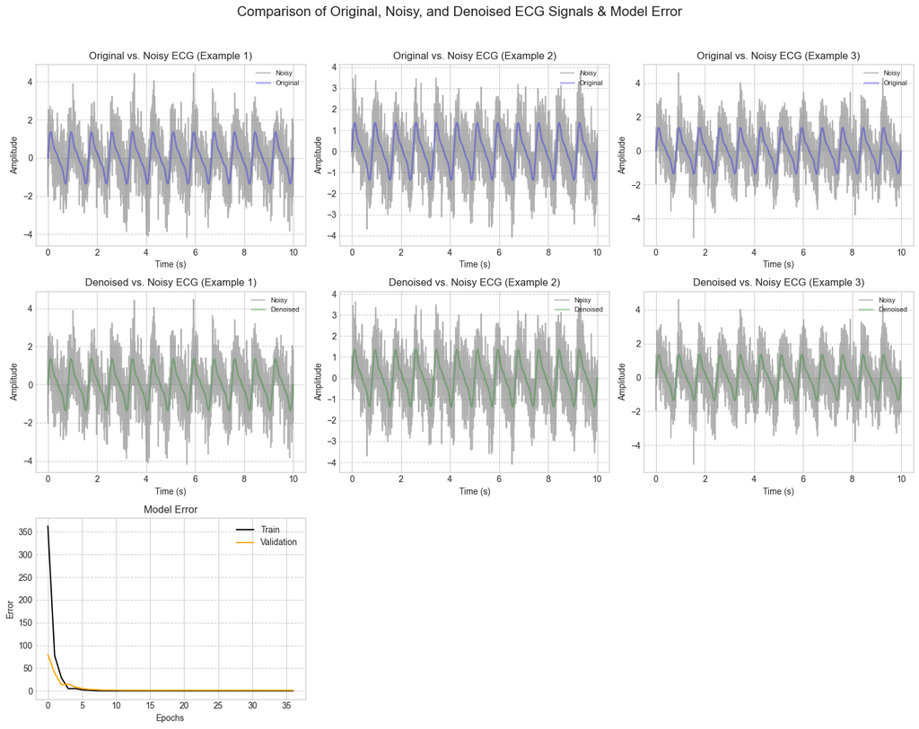

```
6/6 ━━━━━━━━━━━━━━━━━━━━ 2s 74ms/step - loss: 685.8409 - val_loss: 17.9598
6/6 ━━━━━━━━━━━━━━━━━━━━ 0s 39ms/step - loss: 26.9819 - val_loss: 9.4819
6/6 ━━━━━━━━━━━━━━━━━━━━ 0s 41ms/step - loss: 16.0336 - val_loss: 2.6408
6/6 ━━━━━━━━━━━━━━━━━━━━ 0s 38ms/step - loss: 3.0089 - val_loss: 0.8843
6/6 ━━━━━━━━━━━━━━━━━━━━ 0s 42ms/step - loss: 2.0784 - val_loss: 0.6186
6/6 ━━━━━━━━━━━━━━━━━━━━ 0s 40ms/step - loss: 1.2711 - val_loss: 0.3699
6/6 ━━━━━━━━━━━━━━━━━━━━ 0s 46ms/step - loss: 0.4529 - val_loss: 0.2616
6/6 ━━━━━━━━━━━━━━━━━━━━ 0s 41ms/step - loss: 0.3848 - val_loss: 0.2317
6/6 ━━━━━━━━━━━━━━━━━━━━ 0s 41ms/step - loss: 0.3252 - val_loss: 0.0311
6/6 ━━━━━━━━━━━━━━━━━━━━ 0s 39ms/step - loss: 0.3686 - val_loss: 0.0133
6/6 ━━━━━━━━━━━━━━━━━━━━ 0s 38ms/step - loss: 0.0525 - val_loss: 0.5323
6/6 ━━━━━━━━━━━━━━━━━━━━ 0s 38ms/step - loss: 0.7526 - val_loss: 0.0077
6/6 ━━━━━━━━━━━━━━━━━━━━ 0s 39ms/step - loss: 0.0086 - val_loss: 0.0027
6/6 ━━━━━━━━━━━━━━━━━━━━ 0s 40ms/step - loss: 0.0045 - val_loss: 0.0018
6/6 ━━━━━━━━━━━━━━━━━━━━ 0s 39ms/step - loss: 0.0039 - val_loss: 5.4709e-04
6/6 ━━━━━━━━━━━━━━━━━━━━ 0s 42ms/step - loss: 0.0164 - val_loss: 5.4151e-04
6/6 ━━━━━━━━━━━━━━━━━━━━ 0s 62ms/step - loss: 0.0025 - val_loss: 3.5429e-04
6/6 ━━━━━━━━━━━━━━━━━━━━ 0s 40ms/step - loss: 0.0022 - val_loss: 1.2946e-04
6/6 ━━━━━━━━━━━━━━━━━━━━ 0s 38ms/step - loss: 0.0023 - val_loss: 6.5058e-05
6/6 ━━━━━━━━━━━━━━━━━━━━ 0s 39ms/step - loss: 0.0021 - val_loss: 5.5797e-05
6/6 ━━━━━━━━━━━━━━━━━━━━ 0s 45ms/step - loss: 0.0020 - val_loss: 3.9620e-05
6/6 ━━━━━━━━━━━━━━━━━━━━ 0s 39ms/step - loss: 0.0020 - val_loss: 1.6767e-05
6/6 ━━━━━━━━━━━━━━━━━━━━ 0s 39ms/step - loss: 0.0021 - val_loss: 1.0588e-05
6/6 ━━━━━━━━━━━━━━━━━━━━ 0s 44ms/step - loss: 0.0020 - val_loss: 1.0989e-05
6/6 ━━━━━━━━━━━━━━━━━━━━ 0s 40ms/step - loss: 0.0020 - val_loss: 1.2260e-05
6/6 ━━━━━━━━━━━━━━━━━━━━ 0s 56ms/step - loss: 0.0020 - val_loss: 7.0832e-06
6/6 ━━━━━━━━━━━━━━━━━━━━ 0s 39ms/step - loss: 0.0019 - val_loss: 1.0622e-05
6/6 ━━━━━━━━━━━━━━━━━━━━ 0s 39ms/step - loss: 0.0019 - val_loss: 3.0790e-05
6/6 ━━━━━━━━━━━━━━━━━━━━ 0s 39ms/step - loss: 0.0019 - val_loss: 7.7882e-06
6/6 ━━━━━━━━━━━━━━━━━━━━ 0s 39ms/step - loss: 0.0020 - val_loss: 3.8943e-06
6/6 ━━━━━━━━━━━━━━━━━━━━ 0s 40ms/step - loss: 0.0018 - val_loss: 1.6540e-05
6/6 ━━━━━━━━━━━━━━━━━━━━ 0s 43ms/step - loss: 0.0019 - val_loss: 1.4527e-05
6/6 ━━━━━━━━━━━━━━━━━━━━ 0s 40ms/step - loss: 0.0019 - val_loss: 1.1196e-05
6/6 ━━━━━━━━━━━━━━━━━━━━ 0s 40ms/step - loss: 0.0018 - val_loss: 3.0858e-06
6/6 ━━━━━━━━━━━━━━━━━━━━ 0s 54ms/step - loss: 0.0018 - val_loss: 5.3707e-06
6/6 ━━━━━━━━━━━━━━━━━━━━ 0s 40ms/step - loss: 0.0018 - val_loss: 5.1938e-06
6/6 ━━━━━━━━━━━━━━━━━━━━ 0s 39ms/step - loss: 0.0018 - val_loss: 1.3806e-05
6/6 ━━━━━━━━━━━━━━━━━━━━ 0s 38ms/step - loss: 0.0018 - val_loss: 3.2163e-06
6/6 ━━━━━━━━━━━━━━━━━━━━ 0s 38ms/step - loss: 0.0019 - val_loss: 3.1363e-06
6/6 ━━━━━━━━━━━━━━━━━━━━ 0s 42ms/step - loss: 0.0019 - val_loss: 3.0681e-05
6/6 ━━━━━━━━━━━━━━━━━━━━ 0s 43ms/step - loss: 0.0018 - val_loss: 1.5027e-05
6/6 ━━━━━━━━━━━━━━━━━━━━ 0s 40ms/step - loss: 0.0019 - val_loss: 3.6436e-06
6/6 ━━━━━━━━━━━━━━━━━━━━ 0s 39ms/step - loss: 0.0018 - val_loss: 8.6759e-06
6/6 ━━━━━━━━━━━━━━━━━━━━ 0s 57ms/step - loss: 0.0018 - val_loss: 3.4999e-06
32/32 ━━━━━━━━━━━━━━━━━━━━ 0s 4ms/step
```

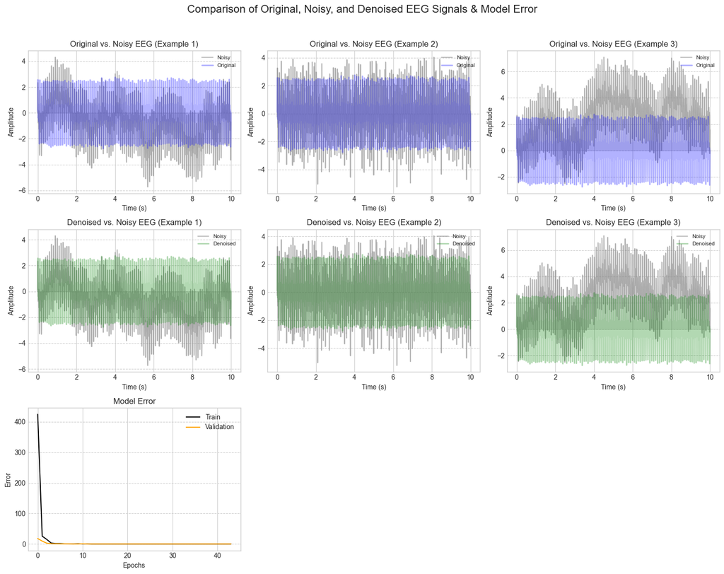

```
6/6 ━━━━━━━━━━━━━━━━━━━━ 2s 78ms/step - loss: 772.2092 - val_loss: 70.8118
6/6 ━━━━━━━━━━━━━━━━━━━━ 0s 78ms/step - loss: 83.2332 - val_loss: 18.5554
6/6 ━━━━━━━━━━━━━━━━━━━━ 0s 51ms/step - loss: 16.0611 - val_loss: 7.4550
6/6 ━━━━━━━━━━━━━━━━━━━━ 0s 44ms/step - loss: 4.1333 - val_loss: 4.8868
6/6 ━━━━━━━━━━━━━━━━━━━━ 0s 44ms/step - loss: 2.4021 - val_loss: 1.1809
6/6 ━━━━━━━━━━━━━━━━━━━━ 0s 38ms/step - loss: 0.6207 - val_loss: 1.1634
6/6 ━━━━━━━━━━━━━━━━━━━━ 0s 38ms/step - loss: 0.3396 - val_loss: 0.5388
6/6 ━━━━━━━━━━━━━━━━━━━━ 0s 38ms/step - loss: 0.1953 - val_loss: 0.5093
6/6 ━━━━━━━━━━━━━━━━━━━━ 0s 38ms/step - loss: 0.0835 - val_loss: 0.3190
6/6 ━━━━━━━━━━━━━━━━━━━━ 0s 40ms/step - loss: 0.2216 - val_loss: 0.1410
6/6 ━━━━━━━━━━━━━━━━━━━━ 0s 38ms/step - loss: 0.0088 - val_loss: 0.8434
6/6 ━━━━━━━━━━━━━━━━━━━━ 0s 46ms/step - loss: 0.2270 - val_loss: 0.1249
6/6 ━━━━━━━━━━━━━━━━━━━━ 0s 38ms/step - loss: 0.0037 - val_loss: 0.1274
6/6 ━━━━━━━━━━━━━━━━━━━━ 0s 40ms/step - loss: 0.0028 - val_loss: 0.1282
6/6 ━━━━━━━━━━━━━━━━━━━━ 0s 38ms/step - loss: 0.0020 - val_loss: 0.1288
6/6 ━━━━━━━━━━━━━━━━━━━━ 0s 37ms/step - loss: 0.0018 - val_loss: 0.1294
6/6 ━━━━━━━━━━━━━━━━━━━━ 0s 37ms/step - loss: 0.0016 - val_loss: 0.1297
6/6 ━━━━━━━━━━━━━━━━━━━━ 0s 38ms/step - loss: 0.0015 - val_loss: 0.1299
6/6 ━━━━━━━━━━━━━━━━━━━━ 0s 38ms/step - loss: 0.0015 - val_loss: 0.1300
6/6 ━━━━━━━━━━━━━━━━━━━━ 0s 54ms/step - loss: 0.0014 - val_loss: 0.1300
6/6 ━━━━━━━━━━━━━━━━━━━━ 0s 37ms/step - loss: 0.0014 - val_loss: 0.1301
6/6 ━━━━━━━━━━━━━━━━━━━━ 0s 36ms/step - loss: 0.0015 - val_loss: 0.1301
32/32 ━━━━━━━━━━━━━━━━━━━━ 0s 5ms/step
```

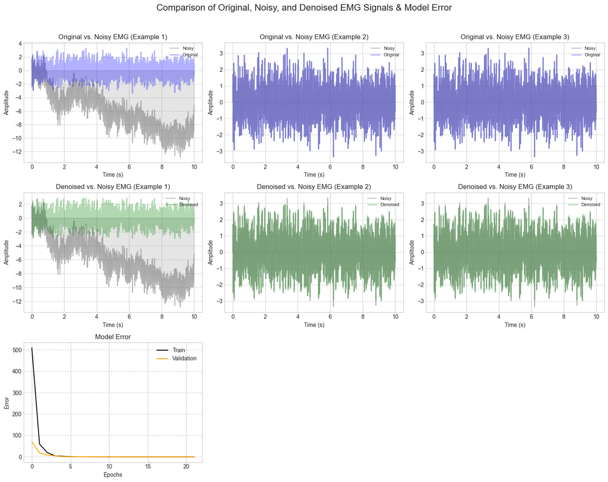

```
6/6 ━━━━━━━━━━━━━━━━━━━━ 2s 71ms/step - loss: 573.3018 - val_loss: 74.4102
6/6 ━━━━━━━━━━━━━━━━━━━━ 0s 40ms/step - loss: 57.4258 - val_loss: 15.3606
6/6 ━━━━━━━━━━━━━━━━━━━━ 0s 38ms/step - loss: 6.7631 - val_loss: 5.3075
6/6 ━━━━━━━━━━━━━━━━━━━━ 0s 36ms/step - loss: 5.2462 - val_loss: 2.6910
6/6 ━━━━━━━━━━━━━━━━━━━━ 0s 37ms/step - loss: 1.2287 - val_loss: 0.9434
6/6 ━━━━━━━━━━━━━━━━━━━━ 0s 36ms/step - loss: 0.3373 - val_loss: 0.5983
6/6 ━━━━━━━━━━━━━━━━━━━━ 0s 36ms/step - loss: 0.4096 - val_loss: 0.1848
6/6 ━━━━━━━━━━━━━━━━━━━━ 0s 35ms/step - loss: 0.0474 - val_loss: 0.2290
6/6 ━━━━━━━━━━━━━━━━━━━━ 0s 46ms/step - loss: 0.2496 - val_loss: 0.1025
6/6 ━━━━━━━━━━━━━━━━━━━━ 0s 38ms/step - loss: 0.0348 - val_loss: 0.0472
6/6 ━━━━━━━━━━━━━━━━━━━━ 0s 39ms/step - loss: 0.0524 - val_loss: 0.0524
6/6 ━━━━━━━━━━━━━━━━━━━━ 0s 42ms/step - loss: 0.0050 - val_loss: 0.1195
6/6 ━━━━━━━━━━━━━━━━━━━━ 0s 36ms/step - loss: 0.0573 - val_loss: 0.0469
6/6 ━━━━━━━━━━━━━━━━━━━━ 0s 37ms/step - loss: 0.0020 - val_loss: 0.0482
6/6 ━━━━━━━━━━━━━━━━━━━━ 0s 36ms/step - loss: 0.0016 - val_loss: 0.0636
6/6 ━━━━━━━━━━━━━━━━━━━━ 0s 37ms/step - loss: 0.0020 - val_loss: 0.0496
6/6 ━━━━━━━━━━━━━━━━━━━━ 0s 38ms/step - loss: 0.0059 - val_loss: 0.0432
6/6 ━━━━━━━━━━━━━━━━━━━━ 0s 36ms/step - loss: 0.0012 - val_loss: 0.0422
6/6 ━━━━━━━━━━━━━━━━━━━━ 0s 49ms/step - loss: 0.0012 - val_loss: 0.0985
6/6 ━━━━━━━━━━━━━━━━━━━━ 0s 37ms/step - loss: 0.0159 - val_loss: 0.0415
6/6 ━━━━━━━━━━━━━━━━━━━━ 0s 39ms/step - loss: 0.0011 - val_loss: 0.0900
6/6 ━━━━━━━━━━━━━━━━━━━━ 0s 38ms/step - loss: 0.0604 - val_loss: 0.0413
6/6 ━━━━━━━━━━━━━━━━━━━━ 0s 36ms/step - loss: 0.0013 - val_loss: 0.6500
6/6 ━━━━━━━━━━━━━━━━━━━━ 0s 36ms/step - loss: 0.3137 - val_loss: 0.0412
6/6 ━━━━━━━━━━━━━━━━━━━━ 0s 36ms/step - loss: 0.0057 - val_loss: 2.0062
6/6 ━━━━━━━━━━━━━━━━━━━━ 0s 35ms/step - loss: 1.0233 - val_loss: 0.2979
6/6 ━━━━━━━━━━━━━━━━━━━━ 0s 36ms/step - loss: 0.3517 - val_loss: 0.0411
6/6 ━━━━━━━━━━━━━━━━━━━━ 0s 36ms/step - loss: 0.0011 - val_loss: 0.0411
6/6 ━━━━━━━━━━━━━━━━━━━━ 0s 53ms/step - loss: 0.0011 - val_loss: 0.0410
6/6 ━━━━━━━━━━━━━━━━━━━━ 0s 41ms/step - loss: 0.0011 - val_loss: 0.0410
6/6 ━━━━━━━━━━━━━━━━━━━━ 0s 35ms/step - loss: 0.0010 - val_loss: 0.0410
6/6 ━━━━━━━━━━━━━━━━━━━━ 0s 37ms/step - loss: 0.0011 - val_loss: 0.0410
6/6 ━━━━━━━━━━━━━━━━━━━━ 0s 36ms/step - loss: 0.0010 - val_loss: 0.0410
6/6 ━━━━━━━━━━━━━━━━━━━━ 0s 37ms/step - loss: 0.0011 - val_loss: 0.0410
6/6 ━━━━━━━━━━━━━━━━━━━━ 0s 35ms/step - loss: 0.0010 - val_loss: 0.0410
6/6 ━━━━━━━━━━━━━━━━━━━━ 0s 37ms/step - loss: 0.0011 - val_loss: 0.0410
6/6 ━━━━━━━━━━━━━━━━━━━━ 0s 36ms/step - loss: 0.0011 - val_loss: 0.0410
6/6 ━━━━━━━━━━━━━━━━━━━━ 0s 45ms/step - loss: 0.0011 - val_loss: 0.0410
6/6 ━━━━━━━━━━━━━━━━━━━━ 0s 36ms/step - loss: 0.0010 - val_loss: 0.0410
6/6 ━━━━━━━━━━━━━━━━━━━━ 0s 39ms/step - loss: 0.0010 - val_loss: 0.0410
6/6 ━━━━━━━━━━━━━━━━━━━━ 0s 38ms/step - loss: 0.0010 - val_loss: 0.0410
6/6 ━━━━━━━━━━━━━━━━━━━━ 0s 37ms/step - loss: 9.7657e-04 - val_loss: 0.0410
6/6 ━━━━━━━━━━━━━━━━━━━━ 0s 38ms/step - loss: 0.0010 - val_loss: 0.0410
6/6 ━━━━━━━━━━━━━━━━━━━━ 0s 36ms/step - loss: 0.0010 - val_loss: 0.0410
32/32 ━━━━━━━━━━━━━━━━━━━━ 0s 4ms/step
```

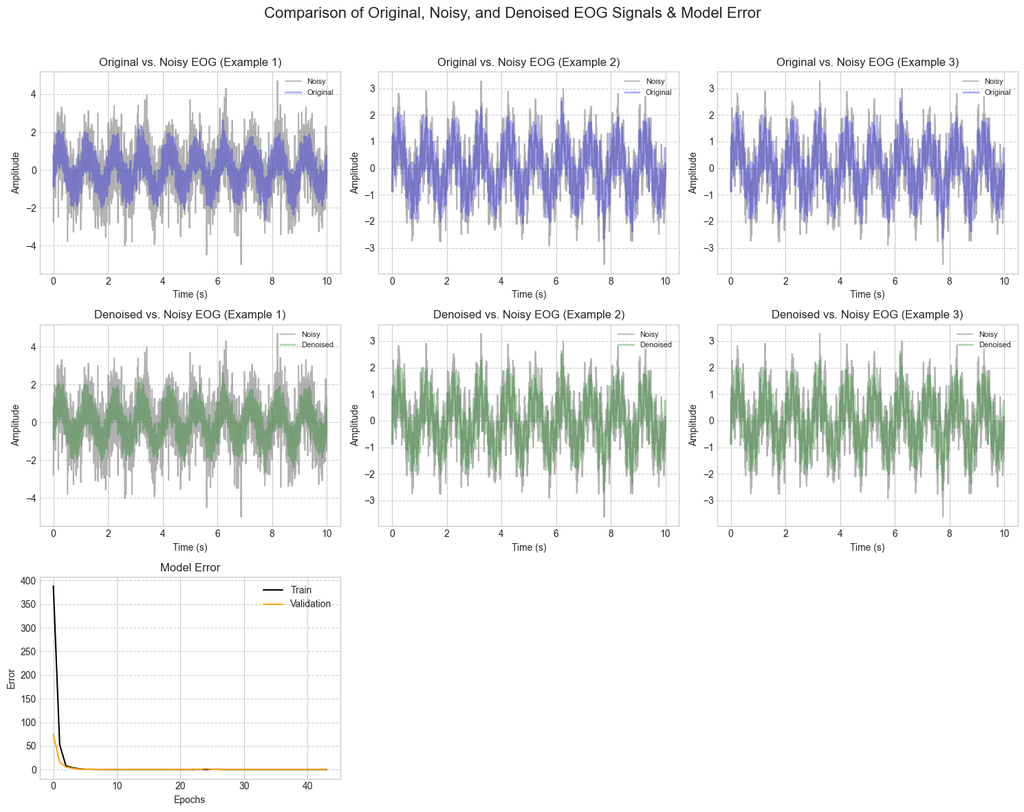

```python
import numpy as np
import matplotlib.pyplot as plt
from tensorflow.keras.layers import Input, Dense, Dropout
from tensorflow.keras.models import Model
from tensorflow.keras.callbacks import EarlyStopping
from tensorflow.keras.optimizers import Adam
from tensorflow.keras.losses import Huber
from tensorflow.keras.regularizers import l2

def generate_signal(duration, frequency, signal_type):
    """Generates a synthetic biomedical signal of the specified type."""
    time = np.linspace(0, duration, int(frequency * duration))

    if signal_type == 'ecg':
        heart_rate = 1.2
        signal = (np.sin(2 * np.pi * heart_rate * time) +
                  0.5 * np.sin(2 * np.pi * 2 * heart_rate * time) +
                  0.2 * np.sin(2 * np.pi * 3 * heart_rate * time))
    elif signal_type == 'eeg':
        signal = (np.sin(2 * np.pi * 10 * time) +
                  np.sin(2 * np.pi * 20 * time) +
                  np.sin(2 * np.pi * 30 * time) +
                  np.random.normal(0, 0.1, len(time)))
    elif signal_type == 'emg':
        signal = np.random.randn(len(time))
    elif signal_type == 'eog':
        signal = np.sin(2 * np.pi * time) + 0.5 * np.random.randn(len(time))
    else:
        raise ValueError(f"Invalid signal type: {signal_type}")

    return time, signal

def add_noise(signal, noise_type, noise_amplitude):
    """Adds specific types of noise to a biomedical signal."""
    t = np.arange(len(signal)) / len(signal)

    if noise_type == 'powerline':
        noise = noise_amplitude * np.sin(2 * np.pi * 50 * t)
    elif noise_type == 'baseline_wander':
        noise = np.cumsum(np.random.normal(0, 0.1, len(signal))) * noise_amplitude
        noise = np.convolve(noise, np.ones(10) / 10, mode='same')
    elif noise_type == 'electrode_motion':
        num_spikes = int(noise_amplitude * len(signal) / 1000)
        spike_indices = np.random.choice(len(signal), num_spikes, replace=False)
        noise = np.zeros(len(signal))
        noise[spike_indices] = np.random.normal(0, noise_amplitude, num_spikes)
    elif noise_type == 'white_noise':
        noise = np.random.normal(0, noise_amplitude, len(signal))
    else:
        raise ValueError(f"Invalid noise type: {noise_type}")

    return signal + noise

def prepare_data_with_noise(signal, num_samples, noise_amplitude):
    """Prepares training data by adding various noise types to the original signal."""
    noise_types = ['powerline', 'baseline_wander', 'electrode_motion', 'white_noise']
    X_train = np.tile(signal, (num_samples, 1))
    X_noisy = []

    for _ in range(num_samples):
        noise_type = np.random.choice(noise_types)
        noisy_signal = add_noise(signal, noise_type, noise_amplitude)
        X_noisy.append(noisy_signal)

    return X_train, np.array(X_noisy)

def prepare_data(duration, frequency, signal_type, num_samples, noise_amplitude):
    """Prepares training and noisy data for the specified signal type."""
    time, signal = generate_signal(duration, frequency, signal_type)
    X_train, X_noisy = prepare_data_with_noise(signal, num_samples, noise_amplitude)
    return time, X_train, X_noisy

def build_autoencoder(input_shape):
    """Constructs a simple autoencoder model for noise reduction."""
    input_signal = Input(shape=input_shape) # Get the input shape of the signal

    # Encoder
    # Map the input signal to a representation
    encoded = Dense(256, activation='relu', activity_regularizer=l2(0.01))(input_signal) # Fisrt layer with 256 neurons, ReLU activation and L2 regularization
    encoded = Dropout(0.2)(encoded) # Dropout layer to prevent overfitting
    encoded = Dense(128, activation='relu')(encoded) # Second layer with 128 neurons and ReLU activation

    # Decoder
    # Map the representation back to the original signal
    decoded = Dense(256, activation='relu')(encoded)
    decoded = Dropout(0.2)(decoded)
    decoded = Dense(input_shape[0], activation='linear')(decoded) # linear activation function for the output layer

    autoencoder = Model(input_signal, decoded)
    autoencoder.compile(optimizer=Adam(learning_rate=0.001), loss=Huber())

    return autoencoder

def plot_signals(time, X_train, X_noisy, denoised_signals, signal_type, history):
    """Plots the original, noisy, denoised signals and the model's training history."""
    plt.style.use('seaborn-v0_8-whitegrid')
    fig, axes = plt.subplots(3, 3, figsize=(15, 12))

    for i in range(3):
        axes[0, i].plot(time, X_noisy[i], color='gray', linestyle='-', alpha=0.5, label='Noisy')
        axes[0, i].fill_between(time, X_noisy[i], color='gray', alpha=0.2)
        axes[0, i].plot(time, X_train[i], color='blue', linestyle='-',alpha=0.3, linewidth=2, label='Original')
        axes[0, i].set_title(f'Original vs. Noisy {signal_type.upper()} (Example {i+1})', fontsize=12)
        axes[0, i].set_xlabel('Time (s)', fontsize=10)
        axes[0, i].set_ylabel('Amplitude', fontsize=10)
        axes[0, i].legend(loc='upper right', fontsize=8)
        axes[0, i].grid(axis='y', linestyle='--')

        axes[1, i].plot(time, X_noisy[i], color='gray', linestyle='-', alpha=0.5, label='Noisy')
        axes[1, i].fill_between(time, X_noisy[i], color='gray', alpha=0.2)
        axes[1, i].plot(time, denoised_signals[i], color='green', alpha=0.3,linestyle='-', linewidth=2, label='Denoised')
        axes[1, i].set_title(f'Denoised vs. Noisy {signal_type.upper()} (Example {i+1})', fontsize=12)
        axes[1, i].set_xlabel('Time (s)', fontsize=10)
        axes[1, i].set_ylabel('Amplitude', fontsize=10)
        axes[1, i].legend(loc='upper right', fontsize=8)
        axes[1, i].grid(axis='y', linestyle='--')

    axes[2, 0].plot(history.history['loss'], color='black')
    axes[2, 0].plot(history.history['val_loss'], color='orange')
    axes[2, 0].set_title('Model Error', fontsize=12)
    axes[2, 0].set_xlabel('Epochs', fontsize=10)
    axes[2, 0].set_ylabel('Error', fontsize=10)
    axes[2, 0].legend(['Train', 'Validation'], loc='upper right')
    axes[2, 0].grid(axis='y', linestyle='--')

    axes[2, 1].axis('off')
    axes[2, 2].axis('off')

    fig.suptitle(f'Comparison of Original, Noisy, and Denoised {signal_type.upper()} Signals & Model Error', fontsize=16)
    plt.tight_layout(rect=[0, 0, 1, 0.96])
    plt.show()

def main(signal_type):
    duration = 10
    frequency = 250
    num_samples = 1000
    noise_amplitude = 1.0

    time, X_train, X_noisy = prepare_data(
        duration,
        frequency,
        signal_type,
        num_samples,
        noise_amplitude
    )

    input_shape = (X_train.shape[1],)
    autoencoder = build_autoencoder(input_shape)

    early_stopping = EarlyStopping(
        monitor='val_loss',
        patience=10,
        restore_best_weights=True
    )

    history = autoencoder.fit(
        X_noisy,
        X_train,
        epochs=100,
        batch_size=128,
        validation_split=0.3,
        callbacks=[early_stopping]
    )

    denoised_signals = autoencoder.predict(X_noisy)

    plot_signals(time, X_train, X_noisy, denoised_signals, signal_type, history)

if __name__ == "__main__":
    for signal_type in ['ecg', 'eeg', 'emg', 'eog']:
        main(signal_type)
```